# 重賞レース予測レポート【毎時自動更新中】

作成日時: 2026/02/22 14:03:24

☞ [マニュアル(pdf)](https://ryutoro-galois.github.io/keiba-predictor/manual/manual.pdf)

☞ 過去6年の同一レース結果: [2025年](https://ryutoro-galois.github.io/keiba-predictor/report/PredResult_2025y_raceDate_20250222_20250223.html), [2024年](https://ryutoro-galois.github.io/keiba-predictor/report/PredResult_2024y_raceDate_20240217_20240218.html), [2023年](https://ryutoro-galois.github.io/keiba-predictor/report/PredResult_2023y_raceDate_20230218_20230219.html), [2022年](https://ryutoro-galois.github.io/keiba-predictor/report/PredResult_2022y_raceDate_20220219_20220220.html), [2021年](https://ryutoro-galois.github.io/keiba-predictor/report/PredResult_2021y_raceDate_20210220_20210221.html), [2020年](https://ryutoro-galois.github.io/keiba-predictor/report/PredResult_2020y_raceDate_20200222_20200223.html)

☞ 過去4週間の別レース結果: [1週前(2/14-15)](https://ryutoro-galois.github.io/keiba-predictor/report/PredResult_2026y_raceDate_20260214_20260215.html), [2週前(2/8)](https://ryutoro-galois.github.io/keiba-predictor/report/PredResult_2026y_raceDate_20260208_20260208.html), [3週前(2/1)](https://ryutoro-galois.github.io/keiba-predictor/report/PredResult_2026y_raceDate_20260201_20260201.html), [4週前(1/24-25)](https://ryutoro-galois.github.io/keiba-predictor/report/PredResult_2026y_raceDate_20260124_20260125.html)

☞ netkeiba: [ダイヤモンドステークス(GⅢ)](https://race.netkeiba.com/race/shutuba.html?race_id=202605010711&rf=race_list), [阪急杯(GⅢ)](https://race.netkeiba.com/race/shutuba.html?race_id=202609010111&rf=race_list), [フェブラリーステークス(GⅠ)](https://race.netkeiba.com/race/shutuba.html?race_id=202605010811&rf=race_list), [小倉大賞典(GⅢ)](https://race.netkeiba.com/race/shutuba.html?race_id=202610011011&rf=race_list)

## 0. 推し馬予測 (AI予測)

### 【ダイヤモンドステークス(GⅢ) 2026/02/21(土)】

- 本命(◎): 1-3着内確率(勝負強さ)が1位の馬
- 対抗(◯): 1-3着内確率が2-N位(20%程度以上)の中で予測タイムが最も速い馬
- 3番手(▲): 1-3着内確率が2-N位(20%程度以上)のでダークホース確率が最も高い馬
- 穴: ダークホース確率が上位1-M位(40%程度以上)の中で1-3着内確率が最も高い馬

| 推し馬 | 枠番 | 馬番 | 人気 | オッズ | 馬名 | 騎手 | 調教師 | 予測タイム(sec) | 1_順位 | 1-3着内確率(%) | 2_順位 | ﾀﾞｰｸﾎｰｽ確率(%) | 3_順位 |
| --- | --- | --- | --- | --- | --- | --- | --- | --- | --- | --- | --- | --- | --- |
| 本命(◎) | 2 | 3 | 3 | 7.8 | ファイアンクランツ | 大野拓弥 | 堀宣行 | 210.2 | 2.5 | 52.1 | 1 | 0.8 | 11 |
| 対抗(◯) | 7 | 13 | 1 | 3.0 | スティンガーグラス | Ｃ．ルメール | 友道康夫 | 210.2 | 2.5 | 25.0 | 2 | 0.6 | 13 |
| 3番手(▲) | 2 | 2 | 4 | 8.0 | ヴェルテンベルク | Ｒ．キング | 宮本博 | 228.8 | 14.0 | 21.0 | 4 | 0.8 | 12 |
| 穴 | 3 | 5 | 14 | 170.0 | トータルクラリティ | 原優介 | 池添学 | 221.8 | 5.0 | 9.9 | 9 | 59.8 | 2 |

### 【阪急杯(GⅢ) 2026/02/21(土)】

- 本命(◎): 1-3着内確率(勝負強さ)が1位の馬
- 対抗(◯): 1-3着内確率が2-N位(20%程度以上)の中で予測タイムが最も速い馬
- 3番手(▲): 1-3着内確率が2-N位(20%程度以上)のでダークホース確率が最も高い馬
- 穴: ダークホース確率が上位1-M位(40%程度以上)の中で1-3着内確率が最も高い馬

| 推し馬 | 枠番 | 馬番 | 人気 | オッズ | 馬名 | 騎手 | 調教師 | 予測タイム(sec) | 1_順位 | 1-3着内確率(%) | 2_順位 | ﾀﾞｰｸﾎｰｽ確率(%) | 3_順位 |
| --- | --- | --- | --- | --- | --- | --- | --- | --- | --- | --- | --- | --- | --- |
| 本命(◎) | 5 | 9 | 2 | 4.7 | マイネルチケット | 横山武史 | 宮徹 | 84.2 | 6 | 44.2 | 1 | 0.4 | 17 |
| 対抗(◯) | 1 | 1 | 1 | 4.2 | ソンシ | 川田将雅 | 中内田充正 | 79.9 | 1 | 25.9 | 4 | 0.5 | 15 |
| 穴 | 7 | 15 | 10 | 35.6 | グロリアラウス | 幸英明 | 斉藤崇史 | 84.9 | 7 | 8.3 | 8 | 23.9 | 4 |

### 【フェブラリーステークス(GⅠ) 2026/02/22(日)】

- 本命(◎): 1-3着内確率(勝負強さ)が1位の馬
- 対抗(◯): 1-3着内確率が2-N位(20%程度以上)の中で予測タイムが最も速い馬
- 3番手(▲): 1-3着内確率が2-N位(20%程度以上)のでダークホース確率が最も高い馬
- 穴: ダークホース確率が上位1-M位(40%程度以上)の中で1-3着内確率が最も高い馬

| 推し馬 | 枠番 | 馬番 | 人気 | オッズ | 馬名 | 騎手 | 調教師 | 予測タイム(sec) | 1_順位 | 1-3着内確率(%) | 2_順位 | ﾀﾞｰｸﾎｰｽ確率(%) | 3_順位 |
| --- | --- | --- | --- | --- | --- | --- | --- | --- | --- | --- | --- | --- | --- |
| 本命(◎) | 3 | 5 | 5 | 14.8 | シックスペンス | 戸崎圭太 | 国枝栄 | 102.4 | 15 | 44.2 | 1 | 1.5 | 12 |
| 対抗(◯) | 5 | 9 | 1 | 2.9 | ダブルハートボンド | 坂井瑠星 | 大久保龍志 | 94.0 | 1 | 27.2 | 6 | 1.2 | 13 |
| 3番手(▲) | 2 | 3 | 10 | 48.2 | ブライアンセンス | 岩田望来 | 斎藤誠 | 101.4 | 10 | 24.1 | 8 | 43.0 | 1 |
| 穴 | 2 | 4 | 9 | 27.8 | ペリエール | 佐々木大輔 | 黒岩陽一 | 101.2 | 8 | 18.1 | 10 | 42.0 | 2 |

### 【小倉大賞典(GⅢ) 2026/02/22(日)】

- 本命(◎): 1-3着内確率(勝負強さ)が1位の馬
- 対抗(◯): 1-3着内確率が2-N位(20%程度以上)の中で予測タイムが最も速い馬
- 3番手(▲): 1-3着内確率が2-N位(20%程度以上)のでダークホース確率が最も高い馬
- 穴: ダークホース確率が上位1-M位(40%程度以上)の中で1-3着内確率が最も高い馬

| 推し馬 | 枠番 | 馬番 | 人気 | オッズ | 馬名 | 騎手 | 調教師 | 予測タイム(sec) | 1_順位 | 1-3着内確率(%) | 2_順位 | ﾀﾞｰｸﾎｰｽ確率(%) | 3_順位 |
| --- | --- | --- | --- | --- | --- | --- | --- | --- | --- | --- | --- | --- | --- |
| 本命(◎) | 5 | 10 | 2 | 5.7 | ケイアイセナ | 藤岡佑介 | 平田修 | 109.5 | 2 | 49.3 | 1 | 0.4 | 13 |
| 対抗(◯) | 7 | 13 | 8 | 13.9 | ガイアメンテ | 北村友一 | 須貝尚介 | 112.1 | 12 | 27.5 | 2 | 1.5 | 9 |
| 3番手(▲) | 5 | 9 | 7 | 13.2 | ナムラエイハブ | 吉田隼人 | 長谷川浩大 | 111.1 | 9 | 11.7 | 6 | 1.1 | 10 |
| 穴 | 6 | 11 | 12 | 28.3 | エピファニー | 杉原誠人 | 宮田敬介 | 112.0 | 11 | 6.1 | 10 | 51.7 | 1 |

## 1. 予測チャート (タイム/勝負強さ)

### 【ダイヤモンドステークス(GⅢ)】

2026/02/21(土), 05_東京, 芝左3400m

[interactive chart not shown]

### 【阪急杯(GⅢ)】

2026/02/21(土), 09_阪神, 芝右1400m

[interactive chart not shown]

### 【フェブラリーステークス(GⅠ)】

2026/02/22(日), 05_東京, ダ左1600m

[interactive chart not shown]

### 【小倉大賞典(GⅢ)】

2026/02/22(日), 10_小倉, 芝右1800m

[interactive chart not shown]

## 2. オッズモニタリング (毎時)

### 【ダイヤモンドステークス】

[interactive chart not shown]

### 【阪急杯】

[interactive chart not shown]

### 【フェブラリーステークス】

[interactive chart not shown]

### 【小倉大賞典】

[interactive chart not shown]

## 3. 出馬表

### 【ダイヤモンドステークス 2026/02/21(土) 】

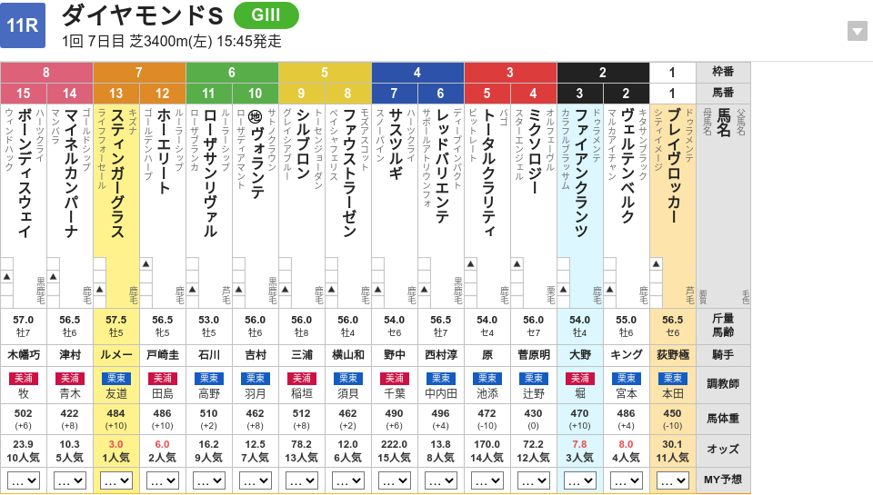

### 【阪急杯 2026/02/21(土) 】

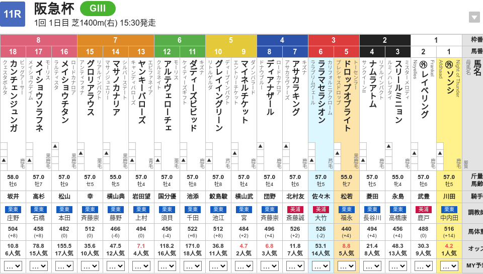

### 【フェブラリーステークス 2026/02/22(日) 】

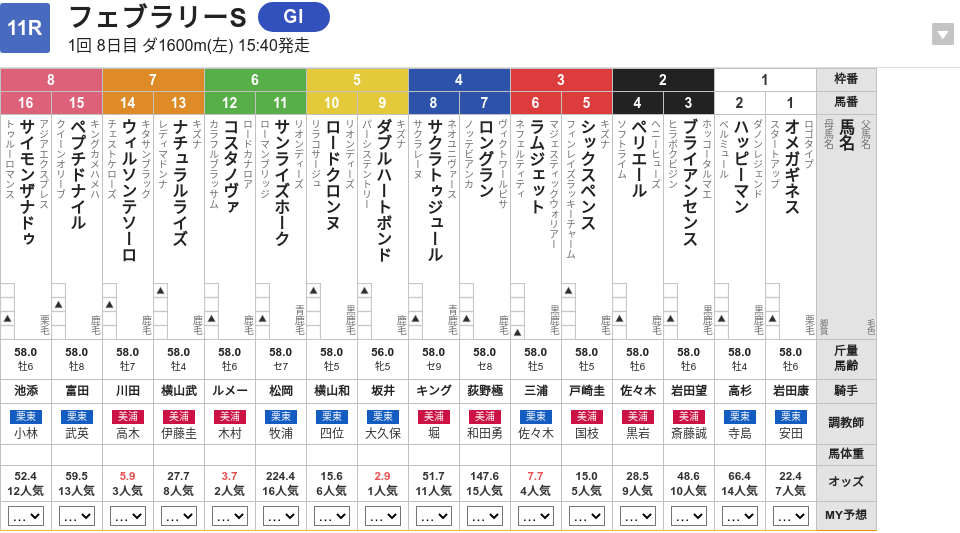

### 【小倉大賞典 2026/02/22(日) 】

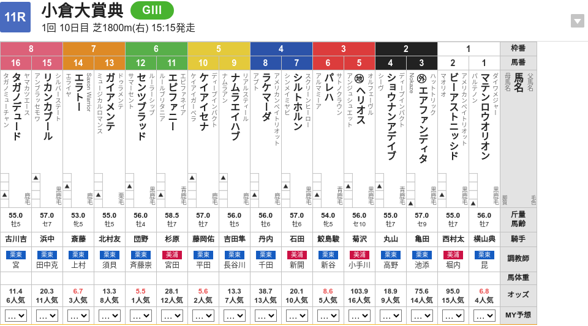

## 4. 単勝予測結果

### 【ダイヤモンドステークス(GⅢ) 2026/02/21(土)】

| 枠番 | 馬番 | 人気 | オッズ | 馬名 | 騎手 | 調教師 | 予測タイム(sec) | 1_順位 | 1-3着内確率(%) | 2_順位 | ﾀﾞｰｸﾎｰｽ確率(%) | 3_順位 |
| --- | --- | --- | --- | --- | --- | --- | --- | --- | --- | --- | --- | --- |
| 1 | 1 | 11 | 30.1 | ブレイヴロッカー | 荻野極 | 本田優 | 229.3 | 15.0 | 2.9 | 14 | 23.2 | 4 |
| 2 | 2 | 4 | 8.0 | ヴェルテンベルク | Ｒ．キング | 宮本博 | 228.8 | 14.0 | 21.0 | 4 | 0.8 | 12 |
| 2 | 3 | 3 | 7.8 | ファイアンクランツ | 大野拓弥 | 堀宣行 | 210.2 | 2.5 | 52.1 | 1 | 0.8 | 11 |
| 3 | 4 | 12 | 72.2 | ミクソロジー | 菅原明良 | 辻野泰之 | 210.2 | 2.5 | 6.1 | 12 | 39.9 | 3 |
| 3 | 5 | 14 | 170.0 | トータルクラリティ | 原優介 | 池添学 | 221.8 | 5.0 | 9.9 | 9 | 59.8 | 2 |
| 4 | 6 | 8 | 13.8 | レッドバリエンテ | 西村淳也 | 中内田充正 | 210.2 | 2.5 | 11.4 | 8 | 1.3 | 9 |
| 4 | 7 | 15 | 222.0 | サスツルギ | 野中悠太郎 | 千葉直人 | 222.7 | 7.0 | 9.0 | 10 | 70.4 | 1 |
| 5 | 8 | 6 | 12.0 | ファウストラーゼン | 横山和生 | 須貝尚介 | 222.9 | 8.0 | 20.0 | 5 | 1.2 | 10 |
| 5 | 9 | 13 | 78.2 | シルブロン | 三浦皇成 | 稲垣幸雄 | 225.7 | 13.0 | 1.8 | 15 | 13.4 | 7 |
| 6 | 10 | 7 | 12.5 | ヴォランテ | 吉村誠之助 | 羽月友彦 | 223.0 | 9.0 | 16.8 | 6 | 1.3 | 8 |

[output cut: 5 more lines]

### 【阪急杯(GⅢ) 2026/02/21(土)】

| 枠番 | 馬番 | 人気 | オッズ | 馬名 | 騎手 | 調教師 | 予測タイム(sec) | 1_順位 | 1-3着内確率(%) | 2_順位 | ﾀﾞｰｸﾎｰｽ確率(%) | 3_順位 |
| --- | --- | --- | --- | --- | --- | --- | --- | --- | --- | --- | --- | --- |
| 1 | 1 | 1 | 4.2 | ソンシ | 川田将雅 | 中内田充正 | 79.9 | 1 | 25.9 | 4 | 0.5 | 15 |
| 1 | 2 | 9 | 30.3 | レイベリング | 武豊 | 鹿戸雄一 | 86.5 | 16 | 13.4 | 6 | 1.5 | 10 |
| 2 | 3 | 13 | 48.3 | スリールミニョン | 永島まなみ | 高橋康之 | 84.2 | 5 | 7.7 | 11 | 39.2 | 1 |
| 2 | 4 | 8 | 21.4 | ナムラアトム | 菱田裕二 | 長谷川浩大 | 85.0 | 8 | 17.1 | 5 | 1.5 | 11 |
| 3 | 5 | 5 | 8.8 | ドロップオブライト | 松若風馬 | 福永祐一 | 85.5 | 12 | 8.3 | 9 | 1.1 | 12 |
| 3 | 6 | 14 | 53.1 | ララマセラシオン | 佐々木大輔 | 大竹正博 | 85.1 | 9 | 3.6 | 18 | 9.9 | 9 |
| 4 | 7 | 7 | 11.8 | アサカラキング | 北村友一 | 斎藤誠 | 86.1 | 15 | 12.9 | 7 | 1.1 | 13 |
| 4 | 8 | 3 | 6.8 | ディアナザール | 団野大成 | 斉藤崇史 | 84.2 | 4 | 34.6 | 2 | 0.4 | 18 |
| 5 | 9 | 2 | 4.7 | マイネルチケット | 横山武史 | 宮徹 | 84.2 | 6 | 44.2 | 1 | 0.4 | 17 |
| 5 | 10 | 11 | 36.8 | グレイイングリーン | 鮫島克駿 | 池江泰寿 | 85.8 | 13 | 5.5 | 15 | 11.2 | 8 |

[output cut: 8 more lines]

### 【フェブラリーステークス(GⅠ) 2026/02/22(日)】

| 枠番 | 馬番 | 人気 | オッズ | 馬名 | 騎手 | 調教師 | 予測タイム(sec) | 1_順位 | 1-3着内確率(%) | 2_順位 | ﾀﾞｰｸﾎｰｽ確率(%) | 3_順位 |
| --- | --- | --- | --- | --- | --- | --- | --- | --- | --- | --- | --- | --- |
| 1 | 1 | 7 | 22.1 | オメガギネス | 岩田康誠 | 安田翔伍 | 101.3 | 9 | 19.2 | 9 | 2.0 | 9 |
| 1 | 2 | 14 | 65.9 | ハッピーマン | 高杉吏麒 | 寺島良 | 100.6 | 6 | 7.0 | 15 | 22.3 | 3 |
| 2 | 3 | 10 | 48.2 | ブライアンセンス | 岩田望来 | 斎藤誠 | 101.4 | 10 | 24.1 | 8 | 43.0 | 1 |
| 2 | 4 | 9 | 27.8 | ペリエール | 佐々木大輔 | 黒岩陽一 | 101.2 | 8 | 18.1 | 10 | 42.0 | 2 |
| 3 | 5 | 5 | 14.8 | シックスペンス | 戸崎圭太 | 国枝栄 | 102.4 | 15 | 44.2 | 1 | 1.5 | 12 |
| 3 | 6 | 4 | 7.7 | ラムジェット | 三浦皇成 | 佐々木晶三 | 99.9 | 4 | 33.8 | 4 | 1.5 | 11 |
| 4 | 7 | 15 | 145.1 | ロングラン | 荻野極 | 和田勇介 | 102.4 | 16 | 10.0 | 13 | 20.5 | 5 |
| 4 | 8 | 11 | 50.6 | サクラトゥジュール | Ｒ．キング | 堀宣行 | 99.5 | 3 | 9.3 | 14 | 20.6 | 4 |
| 5 | 9 | 1 | 2.9 | ダブルハートボンド | 坂井瑠星 | 大久保龍志 | 94.0 | 1 | 27.2 | 6 | 1.2 | 13 |
| 5 | 10 | 6 | 15.4 | ロードクロンヌ | 横山和生 | 四位洋文 | 101.4 | 11 | 25.9 | 7 | 1.6 | 10 |

[output cut: 6 more lines]

### 【小倉大賞典(GⅢ) 2026/02/22(日)】

| 枠番 | 馬番 | 人気 | オッズ | 馬名 | 騎手 | 調教師 | 予測タイム(sec) | 1_順位 | 1-3着内確率(%) | 2_順位 | ﾀﾞｰｸﾎｰｽ確率(%) | 3_順位 |
| --- | --- | --- | --- | --- | --- | --- | --- | --- | --- | --- | --- | --- |
| 1 | 1 | 3 | 6.4 | マテンロウオリオン | 横山典弘 | 昆貢 | 109.6 | 3 | 13.9 | 4 | 0.4 | 16 |
| 1 | 2 | 15 | 88.9 | ビーアストニッシド | 西村太一 | 堀内岳志 | 113.1 | 16 | 5.7 | 11 | 19.9 | 4 |
| 2 | 3 | 14 | 73.9 | エアファンディタ | 亀田温心 | 池添学 | 112.6 | 13 | 5.3 | 12 | 15.0 | 6 |
| 2 | 4 | 9 | 18.7 | ショウナンアデイブ | 丸山元気 | 高野友和 | 112.7 | 14 | 6.3 | 9 | 25.7 | 3 |
| 3 | 5 | 16 | 102.3 | ヘリオス | 菊沢一樹 | 小手川準 | 109.9 | 5 | 5.1 | 13 | 15.3 | 5 |
| 3 | 6 | 5 | 8.9 | パレハ | 鮫島克駿 | 新谷功一 | 110.6 | 8 | 7.7 | 7 | 1.0 | 12 |
| 4 | 7 | 10 | 20.6 | シルトホルン | 石田拓郎 | 新開幸一 | 110.1 | 6 | 3.6 | 14 | 11.1 | 8 |
| 4 | 8 | 13 | 37.6 | ラケマーダ | 丹内祐次 | 千田輝彦 | 109.9 | 4 | 3.1 | 16 | 12.8 | 7 |
| 5 | 9 | 7 | 13.2 | ナムラエイハブ | 吉田隼人 | 長谷川浩大 | 111.1 | 9 | 11.7 | 6 | 1.1 | 10 |
| 5 | 10 | 2 | 5.7 | ケイアイセナ | 藤岡佑介 | 平田修 | 109.5 | 2 | 49.3 | 1 | 0.4 | 13 |

[output cut: 6 more lines]

## 5. 人気と着順の乖離率推移

### 【ダイヤモンドステークス_1990y_2019y】

[interactive chart not shown]

### 【阪急杯_1990y_2019y】

[interactive chart not shown]

### 【フェブラリーステークス_1990y_2019y】

[interactive chart not shown]

### 【小倉大賞典_1990y_2019y】

[interactive chart not shown]

### 【ダイヤモンドステークス_1990y_2019y】

| No | 開催年 | 不整合率(%) | 頭数 | 人気別着順(1-3位) | 人気別着順(全体) |
| --- | --- | --- | --- | --- | --- |
| 30 | 2019 | 31.5 | 10頭 | 1-8-3 | 1\|8\|3\|5\|4\|2\|10\|6\|7\|9 |
| 29 | 2018 | 32.3 | 14頭 | 1-5-6 | 1\|5\|6\|7\|4\|8\|2\|12\|13\|3\|10\|11\|9\|14 |
| 28 | 2017 | 17.9 | 14頭 | 1-6-2 | 1\|6\|2\|14\|5\|3\|4\|12\|11\|15\|10\|8\|9\|13 |
| 27 | 2016 | 36.5 | 16頭 | 4-2-8 | 4\|2\|8\|1\|13\|3\|11\|9\|16\|15\|5\|14\|12\|6\|7\|10 |
| 26 | 2015 | 18.5 | 15頭 | 1-2-8 | 1\|2\|8\|3\|9\|7\|15\|11\|16\|13\|5\|10\|6\|12\|4 |
| 25 | 2014 | 33.8 | 11頭 | 1-5-3 | 1\|5\|3\|4\|9\|6\|10\|2\|11\|7\|8 |
| 24 | 2013 | 32.2 | 16頭 | 1-4-6 | 1\|4\|6\|3\|5\|2\|9\|7\|13\|12\|16\|8\|15\|10\|14\|11 |
| 23 | 2012 | 22.9 | 16頭 | 15-1-2 | 15\|1\|2\|5\|8\|4\|12\|7\|9\|6\|16\|11\|10\|3\|14\|13 |
| 22 | 2011 | 36.1 | 16頭 | 2-4-6 | 2\|4\|6\|1\|9\|5\|12\|7\|11\|15\|10\|3\|14\|13\|16\|8 |
| 21 | 2010 | 35.1 | 15頭 | 1-6-10 | 1\|6\|10\|5\|4\|11\|7\|2\|14\|15\|9\|3\|12\|8\|13 |

[output cut: 20 more lines]

### 【阪急杯_1990y_2019y】

| No | 開催年 | 不整合率(%) | 頭数 | 人気別着順(1-3位) | 人気別着順(全体) |
| --- | --- | --- | --- | --- | --- |
| 30 | 2019 | 51.4 | 18頭 | 11-4-2 | 11\|4\|2\|5\|7\|3\|1\|14\|6\|12\|10\|17\|15\|16\|9\|13\|8\|18 |
| 29 | 2018 | 27.4 | 18頭 | 7-1-2 | 7\|1\|2\|11\|10\|5\|14\|4\|15\|17\|16\|8\|12\|13\|3\|6\|9\|18 |
| 28 | 2017 | 60.3 | 12頭 | 7-4-12 | 7\|4\|12\|3\|11\|5\|9\|1\|2\|6\|8\|10 |
| 27 | 2016 | 29.4 | 18頭 | 1-4-5 | 1\|4\|5\|3\|13\|2\|7\|6\|17\|14\|8\|9\|10\|11\|16\|15\|18\|12 |
| 26 | 2015 | 44.3 | 16頭 | 2-4-9 | 2\|4\|9\|6\|3\|1\|13\|11\|5\|10\|7\|12\|8\|15\|16\|14 |
| 25 | 2014 | 47.6 | 15頭 | 2-8-5 | 2\|8\|5\|3\|9\|4\|13\|7\|1\|10\|6\|11\|15\|16\|12 |
| 24 | 2013 | 16.3 | 16頭 | 1-2-11 | 1\|2\|11\|3\|13\|10\|12\|9\|4\|8\|6\|14\|7\|5\|16\|15 |
| 23 | 2012 | 42.6 | 16頭 | 4-3-1 | 4\|3\|1\|5\|2\|6\|7\|10\|12\|13\|15\|16\|14\|8\|9\|11 |
| 22 | 2011 | 37.0 | 16頭 | 4-1-5 | 4\|1\|5\|3\|2\|9\|10\|7\|11\|6\|8\|15\|16\|12\|13\|14 |
| 21 | 2010 | 43.5 | 16頭 | 2-5-7 | 2\|5\|7\|3\|12\|9\|1\|13\|10\|8\|15\|4\|16\|11\|6\|14 |

[output cut: 20 more lines]

### 【フェブラリーステークス_1990y_2019y】

| No | 開催年 | 不整合率(%) | 頭数 | 人気別着順(1-3位) | 人気別着順(全体) |
| --- | --- | --- | --- | --- | --- |
| 30 | 2019 | 18.8 | 14頭 | 1-2-8 | 1\|2\|8\|9\|4\|5\|6\|11\|14\|3\|10\|12\|7\|13 |
| 29 | 2018 | 44.1 | 16頭 | 4-1-6 | 4\|1\|6\|3\|10\|12\|15\|11\|7\|8\|5\|2\|16\|9\|14\|13 |
| 28 | 2017 | 35.3 | 16頭 | 2-5-1 | 2\|5\|1\|8\|14\|11\|4\|7\|10\|16\|13\|3\|15\|6\|9\|12 |
| 27 | 2016 | 23.1 | 16頭 | 2-1-7 | 2\|1\|7\|3\|6\|9\|4\|10\|13\|5\|11\|8\|15\|16\|12\|14 |
| 26 | 2015 | 28.4 | 16頭 | 1-5-3 | 1\|5\|3\|11\|4\|2\|6\|7\|10\|12\|8\|14\|13\|9\|16\|15 |
| 25 | 2014 | 34.5 | 16頭 | 16-2-1 | 16\|2\|1\|11\|7\|5\|15\|4\|13\|6\|14\|10\|3\|8\|9\|12 |
| 24 | 2013 | 72.0 | 16頭 | 3-9-7 | 3\|9\|7\|16\|5\|13\|4\|10\|8\|6\|11\|2\|12\|14\|1\|15 |
| 23 | 2012 | 54.4 | 16頭 | 7-4-2 | 7\|4\|2\|5\|3\|11\|1\|10\|8\|16\|12\|6\|9\|14\|15\|13 |
| 22 | 2011 | 28.6 | 16頭 | 1-3-4 | 1\|3\|4\|5\|7\|15\|11\|6\|10\|16\|13\|8\|12\|2\|14\|9 |
| 21 | 2010 | 26.5 | 15頭 | 1-5-2 | 1\|5\|2\|14\|6\|10\|8\|15\|7\|4\|11\|3\|12\|13\|9 |

[output cut: 20 more lines]

### 【小倉大賞典_1990y_2019y】

| No | 開催年 | 不整合率(%) | 頭数 | 人気別着順(1-3位) | 人気別着順(全体) |
| --- | --- | --- | --- | --- | --- |
| 30 | 2019 | 41.6 | 14頭 | 3-1-14 | 3\|1\|14\|7\|4\|5\|9\|6\|12\|2\|8\|13\|10\|11 |
| 29 | 2018 | 24.7 | 15頭 | 1-15-4 | 1\|15\|4\|3\|7\|13\|12\|8\|16\|10\|5\|14\|11\|6\|9 |
| 28 | 2017 | 41.3 | 16頭 | 4-8-5 | 4\|8\|5\|11\|1\|6\|12\|13\|16\|14\|10\|2\|15\|9\|7\|3 |
| 27 | 2016 | 53.5 | 16頭 | 2-6-5 | 2\|6\|5\|14\|4\|3\|8\|9\|16\|1\|13\|11\|12\|7\|10\|15 |
| 26 | 2015 | 46.8 | 16頭 | 3-6-11 | 3\|6\|11\|5\|7\|12\|1\|2\|13\|8\|15\|4\|9\|14\|10\|16 |
| 25 | 2014 | 23.5 | 15頭 | 1-8-4 | 1\|8\|4\|9\|2\|6\|3\|13\|15\|5\|10\|11\|7\|12\|14 |
| 24 | 2013 | 44.6 | 16頭 | 6-2-5 | 6\|2\|5\|3\|1\|7\|9\|8\|15\|10\|12\|13\|11\|14\|16\|4 |
| 23 | 2012 | 44.1 | 15頭 | 5-10-1 | 5\|10\|1\|12\|4\|15\|3\|9\|14\|2\|11\|7\|6\|16\|8 |
| 22 | 2011 | 34.3 | 16頭 | 6-9-1 | 6\|9\|1\|10\|5\|14\|2\|8\|11\|4\|15\|12\|3\|13\|7\|16 |
| 21 | 2010 | 58.8 | 15頭 | 7-2-13 | 7\|2\|13\|5\|4\|15\|6\|9\|10\|12\|3\|11\|1\|14\|8 |

[output cut: 20 more lines]

## 6. 1-3番人気馬の着順分類予測

### 【ダイヤモンドステークス】

| 分類 | 凡例 | 発生確率(%) | 当該レース | 当該レースランク | 直近1年間 |
| --- | --- | --- | --- | --- | --- |
| 5: 1,3番人気のみ (5_pop13) | 1 \| 3 \| * | 18.3 | 0.60 | 0.82 | 0.37 |
| 1: 1番人気のみ (1_pop1) | 1 \| * \| * | 16.3 | 0.84 | 0.87 | 0.00 |
| 4: 1,2番人気のみ (4_pop12) | 1 \| 2 \| * | 15.2 | 1.09 | 1.42 | 0.61 |
| 8: 1,2,3番人気すべて着外 (8_darkhorse) | * \| * \| * | 15.0 | 2.68 | 1.40 | 0.00 |
| 3: 3番人気のみ (3_pop3) | 3 \| * \| * | 10.3 | 1.24 | 1.16 | 0.00 |
| 6: 2,3番人気のみ (6_pop23) | 2 \| 3 \| * | 9.2 | 0.83 | 1.03 | 0.00 |
| 2: 2番人気のみ (2_pop2) | 2 \| * \| * | 8.6 | 0.77 | 0.46 | 0.34 |
| 7: 1,2,3番人気すべて着内 (7_pop123) | 1 \| 2 \| 3 | 7.0 | 0.00 | 7.78 | 0.00 |

### 【阪急杯】

| 分類 | 凡例 | 発生確率(%) | 当該レース | 当該レースランク | 直近1年間 |
| --- | --- | --- | --- | --- | --- |
| 1: 1番人気のみ (1_pop1) | 1 \| * \| * | 15.9 | 0.82 | 0.85 | 0.00 |
| 2: 2番人気のみ (2_pop2) | 2 \| * \| * | 15.9 | 0.48 | 0.85 | 0.64 |
| 4: 1,2番人気のみ (4_pop12) | 1 \| 2 \| * | 14.8 | 1.33 | 1.38 | 0.59 |
| 8: 1,2,3番人気すべて着外 (8_darkhorse) | * \| * \| * | 14.7 | 1.32 | 1.37 | 0.00 |
| 5: 1,3番人気のみ (5_pop13) | 1 \| 3 \| * | 12.5 | 1.13 | 0.56 | 0.25 |
| 3: 3番人気のみ (3_pop3) | 3 \| * \| * | 10.2 | 1.82 | 1.15 | 0.00 |
| 6: 2,3番人気のみ (6_pop23) | 2 \| 3 \| * | 9.0 | 1.08 | 1.01 | 0.00 |
| 7: 1,2,3番人気すべて着内 (7_pop123) | 1 \| 2 \| 3 | 7.0 | 0.00 | 7.78 | 0.00 |

### 【フェブラリーステークス】

| 分類 | 凡例 | 発生確率(%) | 当該レース | 当該レースランク | 直近1年間 |
| --- | --- | --- | --- | --- | --- |
| 5: 1,3番人気のみ (5_pop13) | 1 \| 3 \| * | 18.3 | 1.10 | 1.06 | 0.37 |
| 1: 1番人気のみ (1_pop1) | 1 \| * \| * | 16.3 | 1.96 | 4.79 | 0.00 |
| 4: 1,2番人気のみ (4_pop12) | 1 \| 2 \| * | 15.2 | 0.39 | 0.31 | 0.30 |
| 8: 1,2,3番人気すべて着外 (8_darkhorse) | * \| * \| * | 15.0 | 1.81 | 1.46 | 0.00 |
| 3: 3番人気のみ (3_pop3) | 3 \| * \| * | 10.3 | 1.84 | 3.03 | 0.00 |
| 6: 2,3番人気のみ (6_pop23) | 2 \| 3 \| * | 9.2 | 1.64 | 2.71 | 0.00 |
| 2: 2番人気のみ (2_pop2) | 2 \| * \| * | 8.6 | 0.51 | 0.62 | 0.00 |
| 7: 1,2,3番人気すべて着内 (7_pop123) | 1 \| 2 \| 3 | 7.0 | 0.00 | 0.00 | 0.00 |

### 【小倉大賞典】

| 分類 | 凡例 | 発生確率(%) | 当該レース | 当該レースランク | 直近1年間 |
| --- | --- | --- | --- | --- | --- |
| 1: 1番人気のみ (1_pop1) | 1 \| * \| * | 15.9 | 0.95 | 0.91 | 0.00 |
| 2: 2番人気のみ (2_pop2) | 2 \| * \| * | 15.9 | 1.92 | 1.27 | 0.00 |
| 4: 1,2番人気のみ (4_pop12) | 1 \| 2 \| * | 14.8 | 1.78 | 1.97 | 0.30 |
| 8: 1,2,3番人気すべて着外 (8_darkhorse) | * \| * \| * | 14.7 | 0.88 | 0.98 | 0.00 |
| 5: 1,3番人気のみ (5_pop13) | 1 \| 3 \| * | 12.5 | 0.50 | 0.50 | 0.25 |
| 3: 3番人気のみ (3_pop3) | 3 \| * \| * | 10.2 | 0.73 | 0.82 | 0.00 |
| 6: 2,3番人気のみ (6_pop23) | 2 \| 3 \| * | 9.0 | 1.08 | 1.20 | 0.00 |
| 7: 1,2,3番人気すべて着内 (7_pop123) | 1 \| 2 \| 3 | 7.0 | 2.50 | 2.80 | 0.00 |

## 7. 3連複予測結果

### 【ダイヤモンドステークス(GⅢ) 2026/02/21(土)】

| 分類 | 馬番 | 枠番 | 人気 | 平均予測タイム(sec) | 1-3着内確率(%) | ﾀﾞｰｸﾎｰｽ確率(%) | 馬名 | 騎手 | 調教師 |
| --- | --- | --- | --- | --- | --- | --- | --- | --- | --- |
| 5: 1,3番人気のみ (5_pop13) | 13-3-14 | 7-2-8 | 1-3-5 | 214.50 | 2.83 | 0.00 | スティンガーグラス \| ファイアンクランツ \| マイネルカンパーナ | Ｃ．ルメール \| 大野拓弥 \| 津村明秀 | 友道康夫 \| 堀宣行 \| 青木孝文 |
| 5: 1,3番人気のみ (5_pop13) | 13-3-2 | 7-2-2 | 1-3-4 | 216.40 | 2.73 | 0.00 | スティンガーグラス \| ファイアンクランツ \| ヴェルテンベルク | Ｃ．ルメール \| 大野拓弥 \| Ｒ．キング | 友道康夫 \| 堀宣行 \| 宮本博 |
| 5: 1,3番人気のみ (5_pop13) | 13-3-8 | 7-2-5 | 1-3-6 | 214.43 | 2.60 | 0.00 | スティンガーグラス \| ファイアンクランツ \| ファウストラーゼン | Ｃ．ルメール \| 大野拓弥 \| 横山和生 | 友道康夫 \| 堀宣行 \| 須貝尚介 |
| 3: 3番人気のみ (3_pop3) | 3-2-14 | 2-2-8 | 3-4-5 | 220.70 | 2.37 | 0.00 | ファイアンクランツ \| ヴェルテンベルク \| マイネルカンパーナ | 大野拓弥 \| Ｒ．キング \| 津村明秀 | 堀宣行 \| 宮本博 \| 青木孝文 |
| 3: 3番人気のみ (3_pop3) | 3-14-8 | 2-8-5 | 3-5-6 | 218.73 | 2.26 | 0.00 | ファイアンクランツ \| マイネルカンパーナ \| ファウストラーゼン | 大野拓弥 \| 津村明秀 \| 横山和生 | 堀宣行 \| 青木孝文 \| 須貝尚介 |
| 5: 1,3番人気のみ (5_pop13) | 13-3-10 | 7-2-6 | 1-3-7 | 214.47 | 2.18 | 0.00 | スティンガーグラス \| ファイアンクランツ \| ヴォランテ | Ｃ．ルメール \| 大野拓弥 \| 吉村誠之助 | 友道康夫 \| 堀宣行 \| 羽月友彦 |
| 3: 3番人気のみ (3_pop3) | 3-2-8 | 2-2-5 | 3-4-6 | 220.63 | 2.18 | 0.00 | ファイアンクランツ \| ヴェルテンベルク \| ファウストラーゼン | 大野拓弥 \| Ｒ．キング \| 横山和生 | 堀宣行 \| 宮本博 \| 須貝尚介 |
| 3: 3番人気のみ (3_pop3) | 3-14-10 | 2-8-6 | 3-5-7 | 218.77 | 1.90 | 0.00 | ファイアンクランツ \| マイネルカンパーナ \| ヴォランテ | 大野拓弥 \| 津村明秀 \| 吉村誠之助 | 堀宣行 \| 青木孝文 \| 羽月友彦 |
| 3: 3番人気のみ (3_pop3) | 3-2-10 | 2-2-6 | 3-4-7 | 220.67 | 1.83 | 0.00 | ファイアンクランツ \| ヴェルテンベルク \| ヴォランテ | 大野拓弥 \| Ｒ．キング \| 吉村誠之助 | 堀宣行 \| 宮本博 \| 羽月友彦 |
| 7: 1,2,3番人気すべて着内 (7_pop123) | 13-12-3 | 7-7-2 | 1-2-3 | 214.87 | 1.79 | 0.00 | スティンガーグラス \| ホーエリート \| ファイアンクランツ | Ｃ．ルメール \| 戸崎圭太 \| 大野拓弥 | 友道康夫 \| 田島俊明 \| 堀宣行 |

[output cut: 445 more lines]

### 【阪急杯(GⅢ) 2026/02/21(土)】

| 分類 | 馬番 | 枠番 | 人気 | 平均予測タイム(sec) | 1-3着内確率(%) | ﾀﾞｰｸﾎｰｽ確率(%) | 馬名 | 騎手 | 調教師 |
| --- | --- | --- | --- | --- | --- | --- | --- | --- | --- |
| 6: 2,3番人気のみ (6_pop23) | 9-8-13 | 5-4-7 | 2-3-4 | 84.07 | 5.21 | 0.00 | マイネルチケット \| ディアナザール \| ヤンキーバローズ | 横山武史 \| 団野大成 \| 岩田望来 | 宮徹 \| 斉藤崇史 \| 上村洋行 |
| 7: 1,2,3番人気すべて着内 (7_pop123) | 1-9-8 | 1-5-4 | 1-2-3 | 82.77 | 3.95 | 0.00 | ソンシ \| マイネルチケット \| ディアナザール | 川田将雅 \| 横山武史 \| 団野大成 | 中内田充正 \| 宮徹 \| 斉藤崇史 |
| 4: 1,2番人気のみ (4_pop12) | 1-9-13 | 1-5-7 | 1-2-4 | 82.63 | 3.90 | 0.00 | ソンシ \| マイネルチケット \| ヤンキーバローズ | 川田将雅 \| 横山武史 \| 岩田望来 | 中内田充正 \| 宮徹 \| 上村洋行 |
| 5: 1,3番人気のみ (5_pop13) | 1-8-13 | 1-4-7 | 1-3-4 | 82.63 | 3.05 | 0.00 | ソンシ \| ディアナザール \| ヤンキーバローズ | 川田将雅 \| 団野大成 \| 岩田望来 | 中内田充正 \| 斉藤崇史 \| 上村洋行 |
| 6: 2,3番人気のみ (6_pop23) | 9-8-4 | 5-4-2 | 2-3-8 | 84.47 | 2.62 | 0.00 | マイネルチケット \| ディアナザール \| ナムラアトム | 横山武史 \| 団野大成 \| 菱田裕二 | 宮徹 \| 斉藤崇史 \| 長谷川浩大 |
| 2: 2番人気のみ (2_pop2) | 9-13-4 | 5-7-2 | 2-4-8 | 84.33 | 2.58 | 0.00 | マイネルチケット \| ヤンキーバローズ \| ナムラアトム | 横山武史 \| 岩田望来 \| 菱田裕二 | 宮徹 \| 上村洋行 \| 長谷川浩大 |
| 6: 2,3番人気のみ (6_pop23) | 9-8-2 | 5-4-1 | 2-3-9 | 84.97 | 2.04 | 0.00 | マイネルチケット \| ディアナザール \| レイベリング | 横山武史 \| 団野大成 \| 武豊 | 宮徹 \| 斉藤崇史 \| 鹿戸雄一 |
| 3: 3番人気のみ (3_pop3) | 8-13-4 | 4-7-2 | 3-4-8 | 84.33 | 2.02 | 0.00 | ディアナザール \| ヤンキーバローズ \| ナムラアトム | 団野大成 \| 岩田望来 \| 菱田裕二 | 斉藤崇史 \| 上村洋行 \| 長谷川浩大 |
| 2: 2番人気のみ (2_pop2) | 9-13-2 | 5-7-1 | 2-4-9 | 84.83 | 2.01 | 0.00 | マイネルチケット \| ヤンキーバローズ \| レイベリング | 横山武史 \| 岩田望来 \| 武豊 | 宮徹 \| 上村洋行 \| 鹿戸雄一 |
| 6: 2,3番人気のみ (6_pop23) | 9-8-7 | 5-4-4 | 2-3-7 | 84.83 | 1.97 | 0.00 | マイネルチケット \| ディアナザール \| アサカラキング | 横山武史 \| 団野大成 \| 北村友一 | 宮徹 \| 斉藤崇史 \| 斎藤誠 |

[output cut: 806 more lines]

### 【フェブラリーステークス(GⅠ) 2026/02/22(日)】

| 分類 | 馬番 | 枠番 | 人気 | 平均予測タイム(sec) | 1-3着内確率(%) | ﾀﾞｰｸﾎｰｽ確率(%) | 馬名 | 騎手 | 調教師 |
| --- | --- | --- | --- | --- | --- | --- | --- | --- | --- |
| 3: 3番人気のみ (3_pop3) | 14-5-13 | 7-3-7 | 3-5-8 | 99.67 | 7.74 | 0.00 | ウィルソンテソーロ \| シックスペンス \| ナチュラルライズ | 川田将雅 \| 戸崎圭太 \| 横山武史 | 高木登 \| 国枝栄 \| 伊藤圭三 |
| 3: 3番人気のみ (3_pop3) | 14-6-5 | 7-3-3 | 3-4-5 | 101.17 | 6.29 | 0.00 | ウィルソンテソーロ \| ラムジェット \| シックスペンス | 川田将雅 \| 三浦皇成 \| 戸崎圭太 | 高木登 \| 佐々木晶三 \| 国枝栄 |
| 8: 1,2,3番人気すべて着外 (8_darkhorse) | 6-5-13 | 3-3-7 | 4-5-8 | 99.23 | 6.20 | 0.00 | ラムジェット \| シックスペンス \| ナチュラルライズ | 三浦皇成 \| 戸崎圭太 \| 横山武史 | 佐々木晶三 \| 国枝栄 \| 伊藤圭三 |
| 6: 2,3番人気のみ (6_pop23) | 12-14-5 | 6-7-3 | 2-3-5 | 101.20 | 6.08 | 0.00 | コスタノヴァ \| ウィルソンテソーロ \| シックスペンス | Ｃ．ルメール \| 川田将雅 \| 戸崎圭太 | 木村哲也 \| 高木登 \| 国枝栄 |
| 2: 2番人気のみ (2_pop2) | 12-5-13 | 6-3-7 | 2-5-8 | 99.27 | 5.99 | 0.00 | コスタノヴァ \| シックスペンス \| ナチュラルライズ | Ｃ．ルメール \| 戸崎圭太 \| 横山武史 | 木村哲也 \| 国枝栄 \| 伊藤圭三 |
| 3: 3番人気のみ (3_pop3) | 14-6-13 | 7-3-7 | 3-4-8 | 98.83 | 5.92 | 0.00 | ウィルソンテソーロ \| ラムジェット \| ナチュラルライズ | 川田将雅 \| 三浦皇成 \| 横山武史 | 高木登 \| 佐々木晶三 \| 伊藤圭三 |
| 6: 2,3番人気のみ (6_pop23) | 12-14-13 | 6-7-7 | 2-3-8 | 98.87 | 5.72 | 0.00 | コスタノヴァ \| ウィルソンテソーロ \| ナチュラルライズ | Ｃ．ルメール \| 川田将雅 \| 横山武史 | 木村哲也 \| 高木登 \| 伊藤圭三 |
| 5: 1,3番人気のみ (5_pop13) | 9-14-5 | 5-7-3 | 1-3-5 | 99.20 | 5.07 | 0.00 | ダブルハートボンド \| ウィルソンテソーロ \| シックスペンス | 坂井瑠星 \| 川田将雅 \| 戸崎圭太 | 大久保龍志 \| 高木登 \| 国枝栄 |
| 1: 1番人気のみ (1_pop1) | 9-5-13 | 5-3-7 | 1-5-8 | 97.27 | 4.99 | 0.00 | ダブルハートボンド \| シックスペンス \| ナチュラルライズ | 坂井瑠星 \| 戸崎圭太 \| 横山武史 | 大久保龍志 \| 国枝栄 \| 伊藤圭三 |
| 2: 2番人気のみ (2_pop2) | 12-6-5 | 6-3-3 | 2-4-5 | 100.77 | 4.87 | 0.00 | コスタノヴァ \| ラムジェット \| シックスペンス | Ｃ．ルメール \| 三浦皇成 \| 戸崎圭太 | 木村哲也 \| 佐々木晶三 \| 国枝栄 |

[output cut: 550 more lines]

### 【小倉大賞典(GⅢ) 2026/02/22(日)】

| 分類 | 馬番 | 枠番 | 人気 | 平均予測タイム(sec) | 1-3着内確率(%) | ﾀﾞｰｸﾎｰｽ確率(%) | 馬名 | 騎手 | 調教師 |
| --- | --- | --- | --- | --- | --- | --- | --- | --- | --- |
| 4: 1,2番人気のみ (4_pop12) | 12-10-13 | 6-5-7 | 1-2-8 | 108.97 | 2.61 | 0.00 | センツブラッド \| ケイアイセナ \| ガイアメンテ | 団野大成 \| 藤岡佑介 \| 北村友一 | 斉藤崇史 \| 平田修 \| 須貝尚介 |
| 6: 2,3番人気のみ (6_pop23) | 10-1-13 | 5-1-7 | 2-3-8 | 110.40 | 1.88 | 0.00 | ケイアイセナ \| マテンロウオリオン \| ガイアメンテ | 藤岡佑介 \| 横山典弘 \| 北村友一 | 平田修 \| 昆貢 \| 須貝尚介 |
| 2: 2番人気のみ (2_pop2) | 10-14-13 | 5-7-7 | 2-4-8 | 111.43 | 1.86 | 0.00 | ケイアイセナ \| エラトー \| ガイアメンテ | 藤岡佑介 \| 斎藤新 \| 北村友一 | 平田修 \| 上村洋行 \| 須貝尚介 |
| 2: 2番人気のみ (2_pop2) | 10-9-13 | 5-5-7 | 2-7-8 | 110.90 | 1.59 | 0.00 | ケイアイセナ \| ナムラエイハブ \| ガイアメンテ | 藤岡佑介 \| 吉田隼人 \| 北村友一 | 平田修 \| 長谷川浩大 \| 須貝尚介 |
| 7: 1,2,3番人気すべて着内 (7_pop123) | 12-10-1 | 6-5-1 | 1-2-3 | 108.13 | 1.31 | 0.00 | センツブラッド \| ケイアイセナ \| マテンロウオリオン | 団野大成 \| 藤岡佑介 \| 横山典弘 | 斉藤崇史 \| 平田修 \| 昆貢 |
| 4: 1,2番人気のみ (4_pop12) | 12-10-14 | 6-5-7 | 1-2-4 | 109.17 | 1.30 | 0.00 | センツブラッド \| ケイアイセナ \| エラトー | 団野大成 \| 藤岡佑介 \| 斎藤新 | 斉藤崇史 \| 平田修 \| 上村洋行 |
| 4: 1,2番人気のみ (4_pop12) | 12-10-9 | 6-5-5 | 1-2-7 | 108.63 | 1.11 | 0.00 | センツブラッド \| ケイアイセナ \| ナムラエイハブ | 団野大成 \| 藤岡佑介 \| 吉田隼人 | 斉藤崇史 \| 平田修 \| 長谷川浩大 |
| 2: 2番人気のみ (2_pop2) | 10-6-13 | 5-3-7 | 2-5-8 | 110.73 | 1.04 | 0.00 | ケイアイセナ \| パレハ \| ガイアメンテ | 藤岡佑介 \| 鮫島克駿 \| 北村友一 | 平田修 \| 新谷功一 \| 須貝尚介 |
| 2: 2番人気のみ (2_pop2) | 10-16-13 | 5-8-7 | 2-6-8 | 111.03 | 0.94 | 0.00 | ケイアイセナ \| タガノデュード \| ガイアメンテ | 藤岡佑介 \| 古川吉洋 \| 北村友一 | 平田修 \| 宮徹 \| 須貝尚介 |
| 6: 2,3番人気のみ (6_pop23) | 10-1-14 | 5-1-7 | 2-3-4 | 110.60 | 0.94 | 0.00 | ケイアイセナ \| マテンロウオリオン \| エラトー | 藤岡佑介 \| 横山典弘 \| 斎藤新 | 平田修 \| 昆貢 \| 上村洋行 |

[output cut: 550 more lines]

## 8. 直近の全レース情報

[output not shown]